# Business Statistics Mid-Term Assessment IB94X0 2024-2025 #1

5588735

# Section 1

```r
knitr::opts_chunk$set(echo = TRUE)
```

```r
library(tidyverse)
options(width=100)
```

# Loading in the Data

```r
York <- read_csv("York_Footfall_data.csv")
```

# Checking the data integrity/quality

```r
missing_data <- colSums(is.na(York))
missing_data
```

```
##         Date     SiteName LocationName      WeekDay   TotalCount Recording_ID
##            0            0            0            0           10          100
```

```r
clean_data <- York %>%
  filter(TotalCount < 55000)
clean_data
```

```
## # A tibble: 8,179 × 6
##    Date       SiteName LocationName             WeekDay  TotalCount Recording_ID
##    <date>     <chr>    <chr>                    <chr>         <dbl>        <dbl>
##  1 2015-01-01 York     Church Street            Thursday       1952       375836
##  2 2015-01-01 York     Coney Street             Thursday      12220       724862
##  3 2015-01-01 York     Micklegate               Thursday       5559       451020
##  4 2015-01-01 York     Parliament Street at M&S Thursday       7802       523989
##  5 2015-01-01 York     Stonegate                Thursday      14004       382272
##  6 2015-01-02 York     Church Street            Friday         3451       464381
##  7 2015-01-02 York     Coney Street             Friday        31495       654292
##  8 2015-01-02 York     Micklegate               Friday         7055       965489
##  9 2015-01-02 York     Parliament Street at M&S Friday        25427       289782
## 10 2015-01-02 York     Stonegate                Friday        25678       687871
## # ℹ 8,169 more rows
```

# A summary table that shows the date of first and last day / daily mean footfall / standard deviation / highest and lowest daily footfall for each location

```r
#First_day <- min(York$Date)
#Last_day <- max(York$Date)

York_summary_table <- clean_data %>% group_by(LocationName) %>%
  summarise(First_day = min(Date, na.rm=TRUE),
            Last_day = max(Date, na.rm=TRUE),
            mean_footfall=mean(TotalCount, na.rm=TRUE),
            footfall_sd=sd(TotalCount, na.rm=TRUE),
            highest_daily_footfall=max(TotalCount, na.rm=TRUE),
            lowest_daily_footfall=min(TotalCount, na.rm=TRUE))
view(York_summary_table)
```

[output not shown]

# The distribution of footfall across all days, seperated by locations (Plot)

```r
York_2019 <- clean_data %>% filter(year(Date)==2019)
York_2019
```

```
## # A tibble: 1,460 × 6
##    Date       SiteName LocationName      WeekDay   TotalCount Recording_ID
##    <date>     <chr>    <chr>             <chr>          <dbl>        <dbl>
##  1 2019-01-01 York     Coney Street      Tuesday        14804       356061
##  2 2019-01-01 York     Micklegate        Tuesday         5888       773736
##  3 2019-01-01 York     Parliament Street Tuesday         8912       746235
##  4 2019-01-01 York     Stonegate         Tuesday        14573       834721
##  5 2019-01-02 York     Coney Street      Wednesday      23069       347503
##  6 2019-01-02 York     Micklegate        Wednesday       6602       867829
##  7 2019-01-02 York     Parliament Street Wednesday      18485       770169
##  8 2019-01-02 York     Stonegate         Wednesday      19570       992992
##  9 2019-01-03 York     Coney Street      Thursday       22876       631403
## 10 2019-01-03 York     Micklegate        Thursday        7092       583649
## # ℹ 1,450 more rows
```

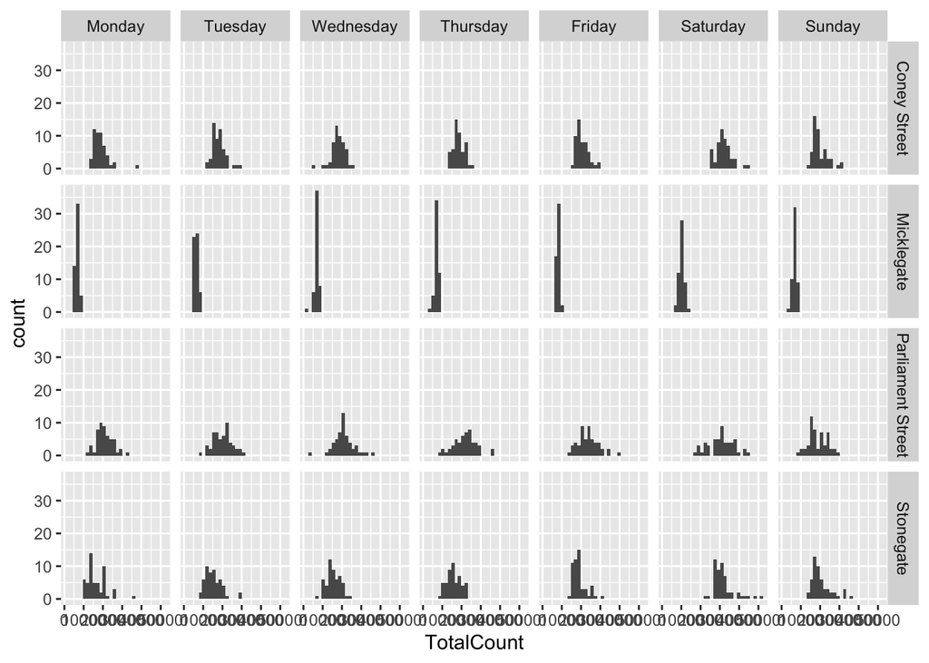

```r
York_2019 <- mutate(York_2019,WeekDay=factor(WeekDay,levels=c("Monday","Tuesday","Wednesday","Thursday","Friday","Saturday","Sunday")))

ggplot(data = York_2019) + geom_histogram(aes(TotalCount)) + facet_grid(LocationName ~ WeekDay)
```

# T-test to compare the footfall on Coney Street to Stonegate

```r
York_t_test <- York_2019 %>% filter(LocationName %in% c("Coney Street", "Stonegate"))
t.test(TotalCount~LocationName, data=York_t_test)
```

```
##
##  Welch Two Sample t-test
##
## data:  TotalCount by LocationName
## t = 3.3611, df = 699.18, p-value = 0.0008186
## alternative hypothesis: true difference in means between group Coney Street and group Stonegate is not equal to 0
## 95 percent confidence interval:
##   670.9189 2555.7989
## sample estimates:
## mean in group Coney Street    mean in group Stonegate
##                   20817.45                   19204.09
```

# Additional t-test to compare the footfall on Coney Street to Stonegate (Only on weekends)

```r
York_add_t_test <- York_2019 %>% filter(LocationName %in% c("Coney Street", "Stonegate") & WeekDay %in% c("Saturday", "Sunday"))

t.test(TotalCount~LocationName, data=York_add_t_test)
```

```
##
##  Welch Two Sample t-test
##
## data:  TotalCount by LocationName
## t = -0.29072, df = 203.88, p-value = 0.7716
## alternative hypothesis: true difference in means between group Coney Street and group Stonegate is not equal to 0
## 95 percent confidence interval:
##  -2362.601  1755.409
## sample estimates:
## mean in group Coney Street    mean in group Stonegate
##                   25863.37                   26166.96
```

# Advise to maximise the number of passers

On weekdays, they should place their stall on Coney Street since it has a higher footfall mean. On the other hand, on weekends, they should place their stall on Stonegrate Street as it shows a higher mean of footfall.

# Section 2

This report shows the results of the footfall data collected in York. First, the quality of the data was checked. It was found that there are 10 missing values in the “TotalCount” column and 100 missing values in the “Recording_ID” column. Also, upon checking the data there were some inaccurate/unreliable values in TotalCount at the end of 2017 specifically in Micklegate and Stonegate. Thus, data-cleaning was applied.

In addition, a t-test was conducted to compare footfall numbers between two specific locations (Coney Street & Stonegate). The results were significant because the p-value was less than 0.05. This means that the null hypothesis of the t-test is rejected, indicating a real difference in footfall between these locations.

Finally, another t-test focused only on footfall data from weekends. In this case, the results were not significant, with a p-value greater than 0.05. Therefore, the null hypothesis for this additional t-test is accepted, suggesting no significant difference in weekend footfall between the locations analysed.